# Marine Heatwave Simulation Analysis

Andrew Villeneuve

2024-01-12

# Data analysis introduction

The below analysis creates all figures in Villeneuve and White 2024 MHW simulation paper. The document can be knitted to reproduce the entire analysis. All chunks of this markdown can be run as well, but certain chunks are computationally intensive and can take many hours to complete. These time-consuming chunks are labelled. In key places, we have saved .RDs data files of computational outputs at strategic checkpoints to allow for rapid knitting of the document. These .RDs files are included in the repository for convenience, but are not included in github due to size restrictions.

Two exterior R files are called to define functions used in this analysis. They are as follows:

- hour_fxns_heatwaveR.R - This file contains ad hoc functions drawn from the heatwaveR package (Schlegel and Smit 2018). We edited these functions for our own use to allow for input of hourly data.
- Thermal_landscape_functions.R - This file contains ad hoc functions drawn from Rezende et al. (2020) to calculate static thermal tolerance landscapes and calculate survival over variable temperature time series using a dynamic thermal tolerance model. We edited these functions to incorporate the concept of critical temperature Jørgensen et al. (2021) , the temperature at which temperature stress starts to become lethal.

# A function for constructing all possible MHWs from a set of parameters

The first step in this project is to create a function that allows for the construction of all possible MHWs from a range of values for each parameter (magnitude, duration, and rate of onset). For rate of onset, we use duration of onset instead of slope itself, as slope is dependent on magnitude of each event.

Below, we set up the range of parameters. All times must be in minutes, all temperatures are in degrees Celsius.

```r
magnitude_min<-0.01 #0.01 degree minimum magnitude. Analysis does not accept 0 value
magnitude_max<-8.01 #8 degree duration max. This is in agreement with observed values above climatology across multiple major MHW events
duration_min<-60*1 #one hour MHW min  Here, we differ from other definitions (Hobday et al. 2016) that set minimum values of 5 days for a MHW event. For intertidal organisms, a few hours of extreme heat during low tide during an atmospheric heatwave may cause mortality and should be considered from an ecophysiological perspective.
duration_max<-24*30*60+60*1 # 30 day MHW max - MHWs can commonly last multiple days, weeks, or months. However, for the sake of this initial analysis, we reduce that to three day for speed of calculation.Note that this is technically 30 days plus one hour, to keep intervals between durations the same.

magnitude_inc<-0.5 # magnitudes given in 0.5 degree increments
duration_inc<-24*60 #durations given in 24 hour increments (MUST be in minutes)
```

Now, we can set up the function that creates all possible plateau possibilities from this range of parameters. Note that you must change where the R data file (.RDs) are saved - here, I save them in my personal onedrive folder due to space restrictions on github.

Here, we can see the resulting triangles from our range of parameters.

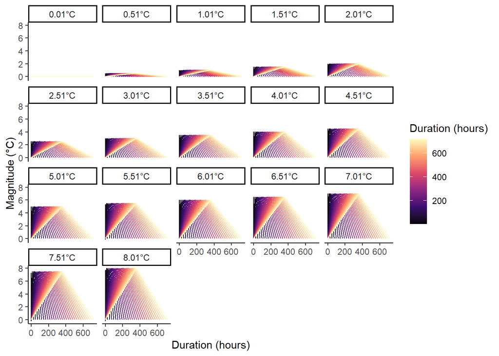

# Simulating annual time series

Now that we have simulated MHW triangles, we need to add these on top of a typical temperature time series for a given location. First, let’s simulate one year of data using a sine wave, then add oceanographic, fixed baseline categories of MHWs Hobday et al. (2018).

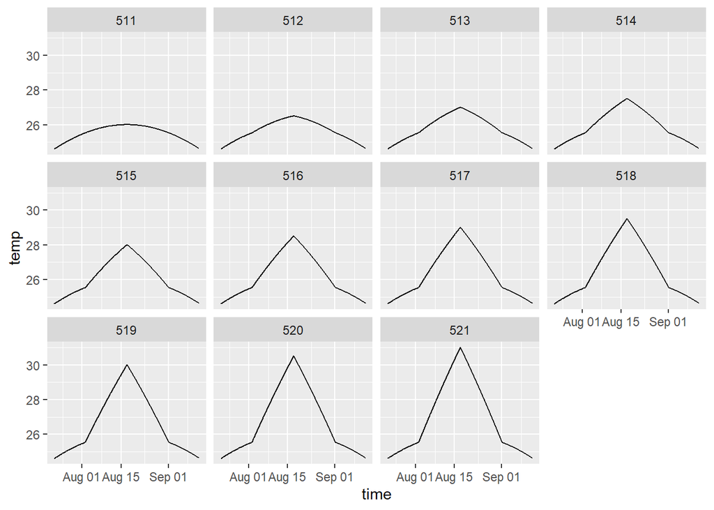

# Two Hypothetical Species

Next, we want to simulate TDT curves for two hypothetical species. We can do this by getting two CTmax and two z parameters, and making TDT curves from those parameters. We will demonstrate here a chronic vs. acute tradeoff.

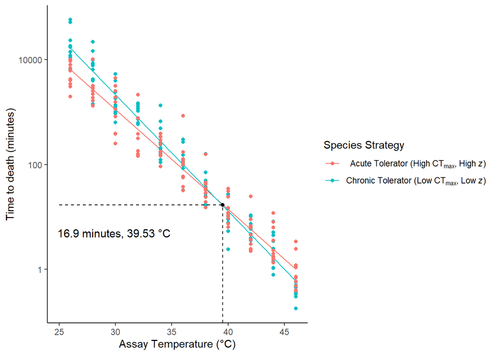

# Both species

Now, we can run the simulated TDT curve with the environmental data to get an estimate of mortality for both species

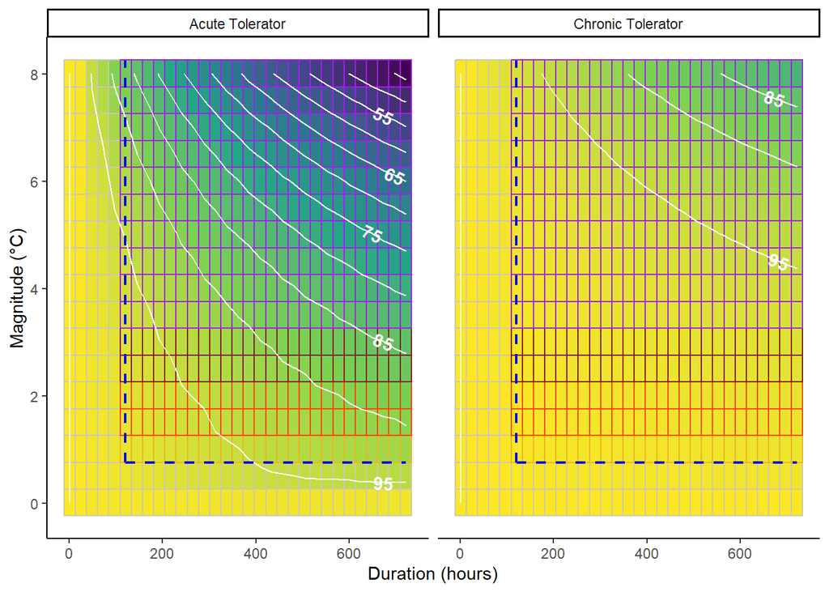

Now, let’s see how altering the thermal adaptation strategy changes sensitivity to different oceanographic definitions of MHWs

```
## Table for Chronic Tolerator :
## ------------------------------
##
##              100  95  90  85  80  75  70  65  60  55  50  45
##   No MHW     137   0   0   0   0   0   0   0   0   0   0   0
##   I Moderate  26   0   0   0   0   0   0   0   0   0   0   0
##   II Strong   52   0   0   0   0   0   0   0   0   0   0   0
##   III Severe  52   0   0   0   0   0   0   0   0   0   0   0
##   IV Extreme 143  78  30   9   0   0   0   0   0   0   0   0
##
##
## Table for Acute Tolerator :
## ------------------------------
##
##              100  95  90  85  80  75  70  65  60  55  50  45
##   No MHW     116  20   1   0   0   0   0   0   0   0   0   0
##   I Moderate  11  15   0   0   0   0   0   0   0   0   0   0
##   II Strong   14  31   7   0   0   0   0   0   0   0   0   0
##   III Severe   9  20  21   2   0   0   0   0   0   0   0   0
##   IV Extreme   6  34  43  50  36  27  22  16  12   7   5   2
```

```
##   cum.mort magnitude duration rising_slope falling_slope    area rep mean_i
## 1 89.27333      8.01     5820  0.002752577             0 23309.1  85  4.005
##        hdd duration_hob  peak_date category imax_hob p_moderate p_strong
## 1 16.26469         5275 1660723080   No MHW     8.01         10       10
##   p_severe p_extreme      species alpha ceilingmort ceilingmort_f  leveldens
## 1       10        69 highct_highz 12.75          90            90 0.00729927
##   hours_dur           label
## 1        97 Acute Tolerator
```

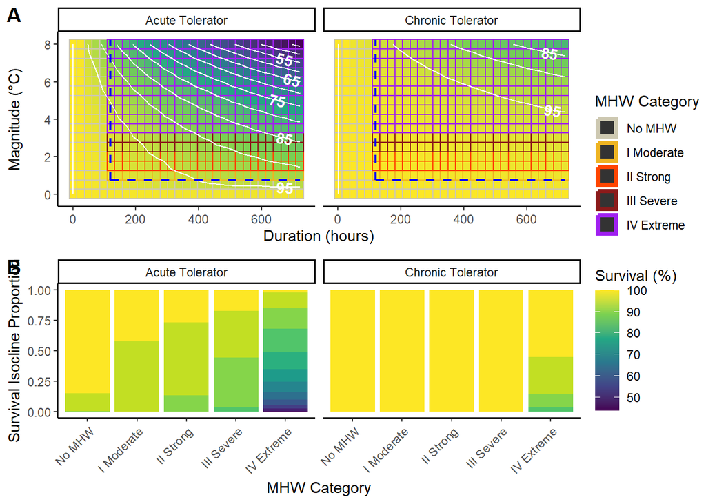

# All Alphas (Annual variability)

Now, we can look at one ‘species’ and how changing variation changes MHW categories. We will classify MHWs using the three different 90th percentile thresholds we calcualted earlier, at 0.25, 0.75, and 1.5 oC above climatology.

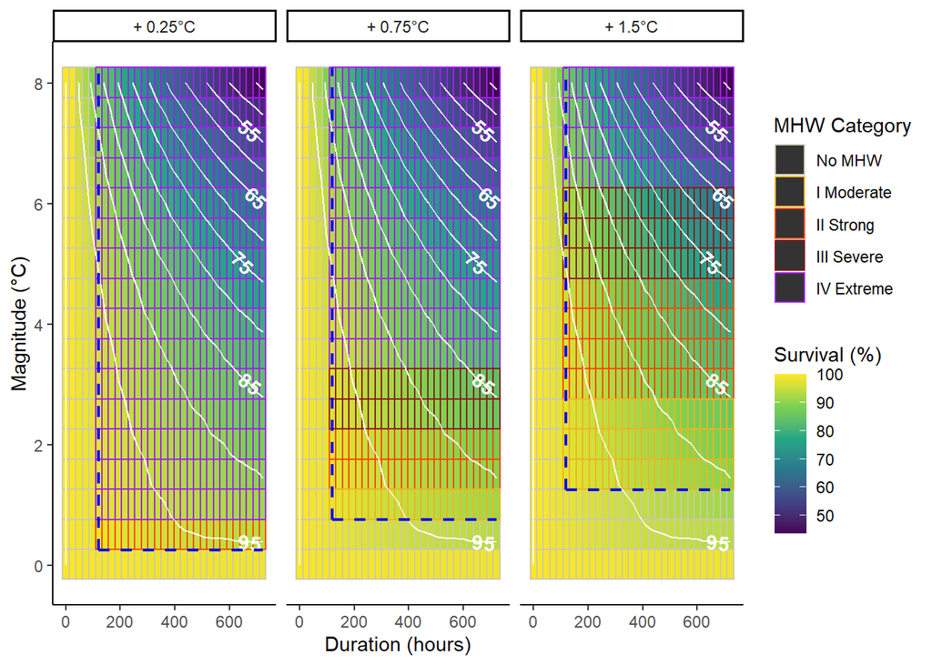

Now, let’s see how altering seasonal variability changes sensitivity to different oceanographic definitions of MHWs

```
## Table for + 0.25°C :
## ------------------------------
##
##              100  95  90  85  80  75  70  65  60  55  50  45
##   No MHW     101   9   1   0   0   0   0   0   0   0   0   0
##   I Moderate   0   0   0   0   0   0   0   0   0   0   0   0
##   II Strong   15  11   0   0   0   0   0   0   0   0   0   0
##   III Severe   0   0   0   0   0   0   0   0   0   0   0   0
##   IV Extreme  40 100  71  52  36  27  22  16  12   7   5   2
##
##
## Table for + 0.75°C :
## ------------------------------
##
##              100  95  90  85  80  75  70  65  60  55  50  45
##   No MHW     116  20   1   0   0   0   0   0   0   0   0   0
##   I Moderate  11  15   0   0   0   0   0   0   0   0   0   0
##   II Strong   14  31   7   0   0   0   0   0   0   0   0   0
##   III Severe   9  20  21   2   0   0   0   0   0   0   0   0
##   IV Extreme   6  34  43  50  36  27  22  16  12   7   5   2
##
##
## Table for + 1.5°C :
## ------------------------------
##
##              100  95  90  85  80  75  70  65  60  55  50  45
##   No MHW     127  35   1   0   0   0   0   0   0   0   0   0
##   I Moderate  19  42  17   0   0   0   0   0   0   0   0   0
##   II Strong   10  28  34  24   8   0   0   0   0   0   0   0
##   III Severe   0  12  12  16  16  15   6   1   0   0   0   0
##   IV Extreme   0   3   8  12  12  12  16  15  12   7   5   2
```

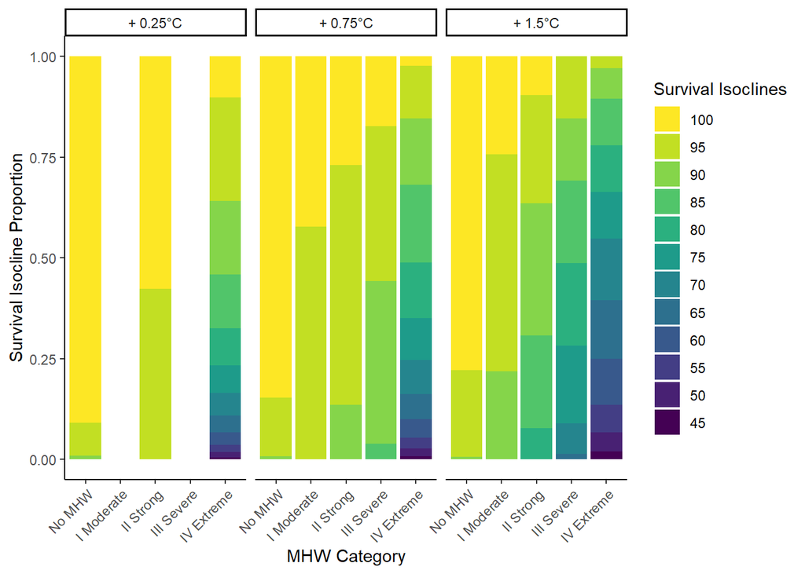

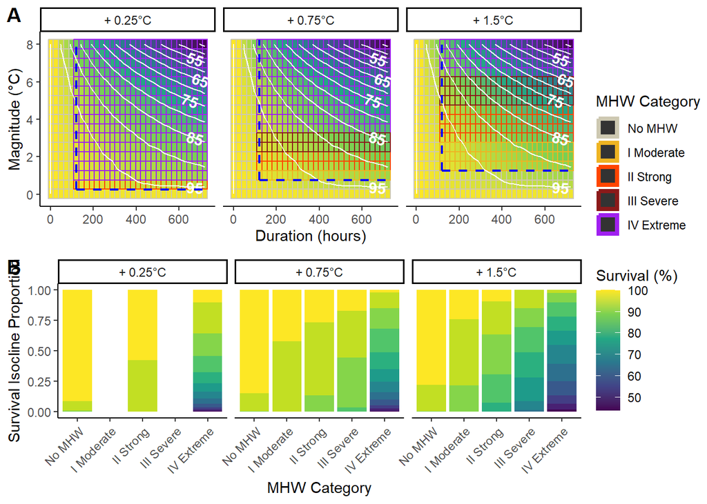

# Seasonality

Now, let’s simulate the effect of seasonal occurrence on mortality arising from MHWs.We only look at a single duration (24 days) but the same 17 magnitudes from 0 to 8.

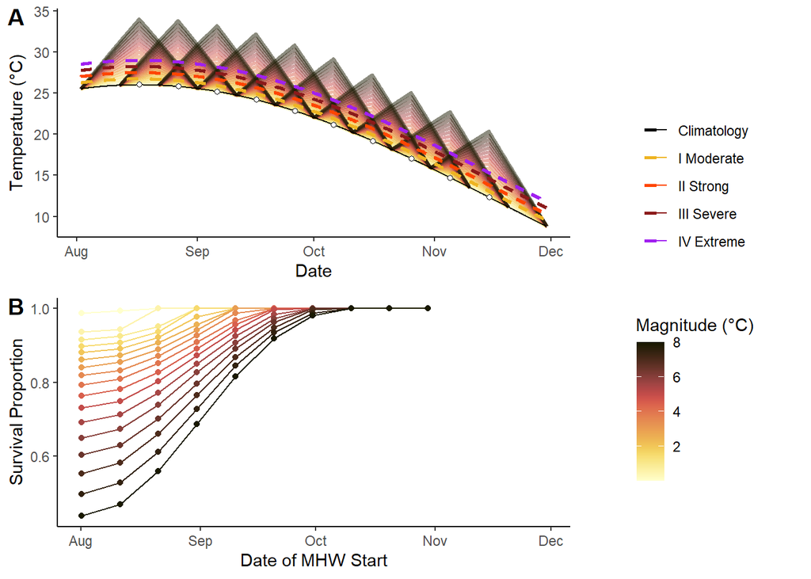

Below we see how the seasonal occurrence of a MHW impacts cumulative survival at the end of each MHW across magnitudes

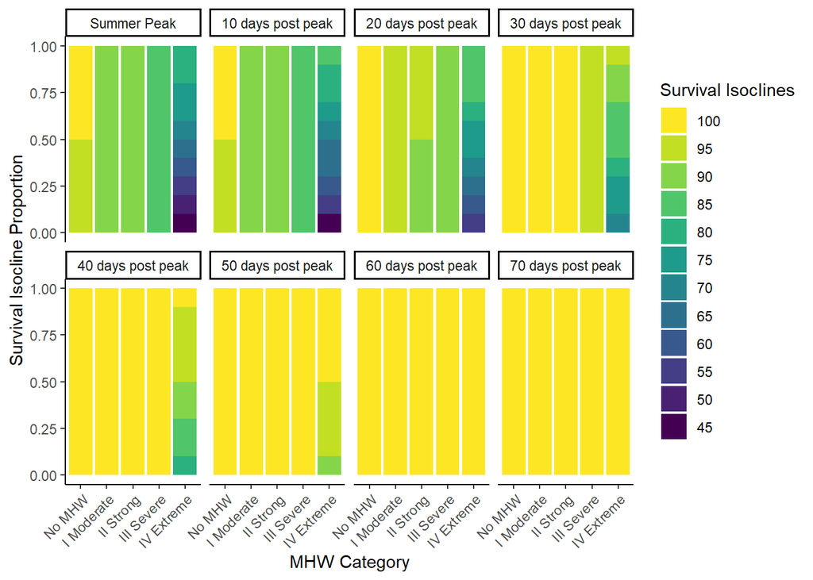

# Citations

Hobday, Alistair J., Eric Oliver, Alex Sen Gupta, Jessica Benthuysen, Michael Burrows, Markus Donat, Neil Holbrook, et al. 2018. “Categorizing and Naming Marine Heatwaves.” *Oceanography* 31 (2). https://doi.org/10.5670/oceanog.2018.205.

Jørgensen, Lisa Bjerregaard, Hans Malte, Michael Ørsted, Nikolaj Andreasen Klahn, and Johannes Overgaard. 2021. “A Unifying Model to Estimate Thermal Tolerance Limits in Ectotherms Across Static, Dynamic and Fluctuating Exposures to Thermal Stress.” *Scientific Reports* 11 (June): 12840. https://doi.org/10.1038/s41598-021-92004-6.

Rezende, Enrico L., Francisco Bozinovic, András Szilágyi, and Mauro Santos. 2020. “Predicting Temperature Mortality and Selection in Natural Drosophila Populations.” *Science* 369 (6508): 1242–45. https://doi.org/10.1126/science.aba9287.

Schlegel, Robert W., and Albertus J. Smit. 2018. “heatwaveR: A Central Algorithm for the Detection of Heatwaves and Cold-Spells.” *Journal of Open Source Software* 3 (27): 821. https://doi.org/10.21105/joss.00821.